# check the hcaf dataset

2020-04-22

### Check the parameters

The estimated $\Gamma_1$ and $\Gamma_2$ values are:

$\hat \Gamma_1:$

```
## [1] -0.1537  0.0094
```

$\hat \Gamma_2:$

```
## [1] -0.0591 -0.0275
```

```r
angle = cosine(gamma1, gamma2)
acos(angle) * pi / 180
```

```
##             [,1]
## [1,] 0.008667739
```

#### Draw the animation to show the movements

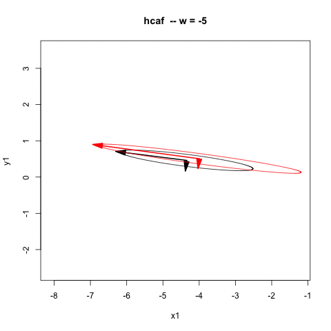

### The IPWE calculation

10 folds cross validations. 100 repetitions.

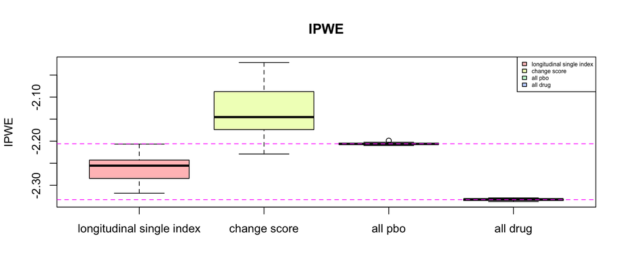

### The trajectories

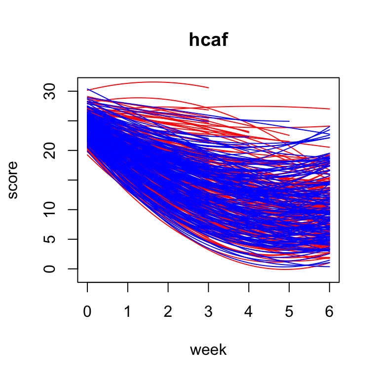

Fit the linear mixed effect model (Y ~ week)

```r
fit_pbo_est = lmer(y ~ tt + I(tt^2)  + (tt + I(tt^2)|subj),
                   data = dat_pbo_est, REML = FALSE)
fit_drg_est = lmer(y ~ tt + I(tt^2)  + (tt + I(tt^2)|subj),
                   data = dat_drg_est, REML = FALSE)
```

Then fit the parabolas by
$$Y = e_1 + e_2 t + e_3 t^2$$
where $e = [e_1, e_2, e_3] \in \text{coef(fit_pbo_est), coef(fit_drg_est)}$

#### Draw the trajectory (drg, pbo)

- The subjects whose estimation of assignment is “placebo” by applying change score method
- The subjects whose estimation of assignment is “drug” by applying change score method

i,e, * $\hat n_{pbo}$: lables sets of subjects who is estimated to be assigned into placebo group * $\hat n_{drg}$: lables sets of subjects who is estimated to be assigned into drug group

The red trajectories are drawn by
$$Y = e_1 + e_2 t + e_3 t^2$$
where $e = [e_1, e_2, e_3] \in \{ \text{coef(fit_pbo_est), coef(fit_drg_est)} ; \text{coef(fit_pbo_est)}_i \in \hat n_{pbo}, \text{coef(fit_drg_est)} \in \hat n_{pbo}\}$

The blue trajectories are drawn by
$$Y = e_1 + e_2 t + e_3 t^2$$
where $e = [e_1, e_2, e_3] \in \{ \text{coef(fit_pbo_est), coef(fit_drg_est)} ; \text{coef(fit_pbo_est)}_i \in \hat n_{drg}, \text{coef(fit_drg_est)} \in \hat n_{drg}\}$

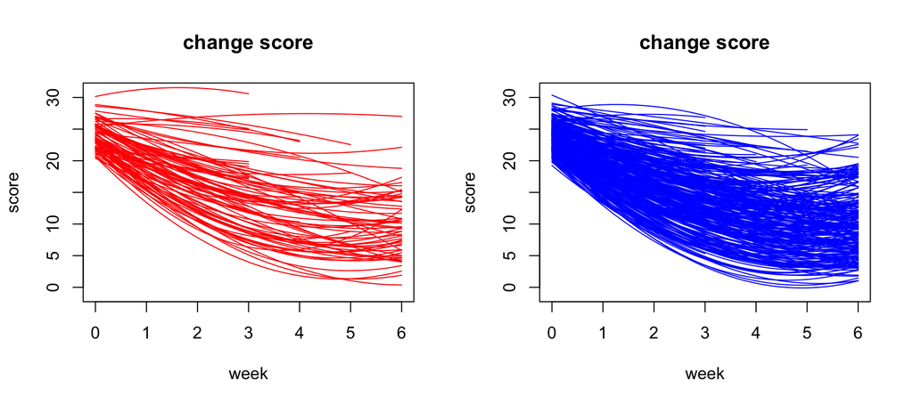

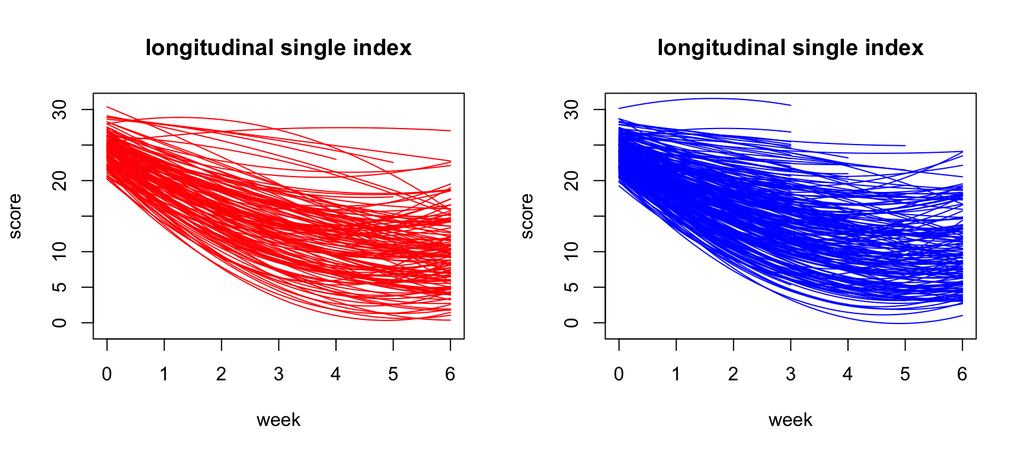